# DATA 607 - Project 2.3

Simon63

March 12, 2018

```r
# install.packages("tidyverse")
library(readxl)
library(tidyr)
library(dplyr)
library(stringr)
library(ggplot2)
```

My Post: “World Tourism Data”  
http://data.un.org/DocumentData.aspx?id=375  
The data looks pretty “untidy” and one can transform it and perform several analysis, such as comparing Inbound vs. Outbound tourism numbers, detecting trends through the years, comparing numbers between countries, and etc.

Downloaded XLS file, “Arrivals of non resident tourists_visitors, depart.xls” and saved it as “World Tourism Data.xlsx”

Here’s how the data looks initially: image:

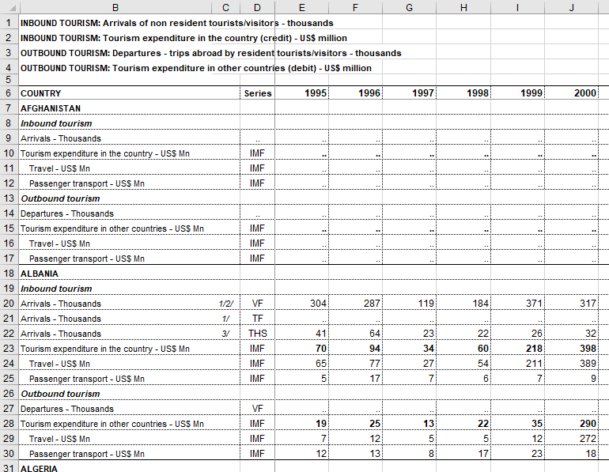

Read XLSX File, skiping the first 5 rows in order to get to proper headers

```r
# Get path [in platform independent way using file.path() function]
path <- file.path("~", "R", "Project 2", "World Tourism Data.xlsx")
df <-  read_xlsx(path, skip = 5) %>% tbl_df()
df
```

```
## # A tibble: 2,465 x 25
##     X__1 COUNTRY    X__2  Series `1995` `1996` `1997` `1998` `1999` `2000`
##    <dbl> <chr>      <chr> <chr>  <chr>  <chr>  <chr>  <chr>  <chr>  <chr>
##  1    4. AFGHANIST~ <NA>  <NA>   <NA>   <NA>   <NA>   <NA>   <NA>   <NA>
##  2   NA  Inbound t~ <NA>  <NA>   <NA>   <NA>   <NA>   <NA>   <NA>   <NA>
##  3   NA  Arrivals ~ <NA>  ..     ..     ..     ..     ..     ..     ..
##  4   NA  Tourism e~ <NA>  IMF    ..     ..     ..     ..     ..     ..
##  5   NA  Travel - ~ <NA>  IMF    ..     ..     ..     ..     ..     ..
##  6   NA  Passenger~ <NA>  IMF    ..     ..     ..     ..     ..     ..
##  7   NA  Outbound ~ <NA>  <NA>   <NA>   <NA>   <NA>   <NA>   <NA>   <NA>
##  8   NA  Departure~ <NA>  ..     ..     ..     ..     ..     ..     ..
##  9   NA  Tourism e~ <NA>  IMF    ..     ..     ..     ..     ..     ..
## 10   NA  Travel - ~ <NA>  IMF    ..     ..     ..     ..     ..     ..
## # ... with 2,455 more rows, and 15 more variables: `2001` <chr>,
## #   `2002` <chr>, `2003` <chr>, `2004` <chr>, `2005` <chr>, `2006` <chr>,
## #   `2007` <chr>, `2008` <chr>, `2009` <chr>, `2010` <chr>, `2011` <chr>,
## #   `2012` <chr>, `2013` <chr>, `2014` <chr>, NOTES <chr>
```

I decided to look at the data for North America: rows [419:429] for CANADA and rows [2340:2350] for USA

```r
dfCAN <- df[419:429, ]
dfUSA <- df[2340:2350, ]
```

Data displayed for CANADA

```r
  head(dfCAN, n = (429-419))
```

```
## # A tibble: 10 x 25
##     X__1 COUNTRY    X__2  Series `1995` `1996` `1997` `1998` `1999` `2000`
##    <dbl> <chr>      <chr> <chr>  <chr>  <chr>  <chr>  <chr>  <chr>  <chr>
##  1  124. CANADA     <NA>  <NA>   <NA>   <NA>   <NA>   <NA>   <NA>   <NA>
##  2   NA  Inbound t~ <NA>  <NA>   <NA>   <NA>   <NA>   <NA>   <NA>   <NA>
##  3   NA  Arrivals ~ <NA>  TF     16932  17286  17669  18870  19411  19627
##  4   NA  Tourism e~ <NA>  IMF    9176   10073  10390  11049  12024  13035
##  5   NA  Travel - ~ <NA>  IMF    7917   8607   8819   9414   10203  10778
##  6   NA  Passenger~ <NA>  IMF    1259   1466   1571   1635   1821   2257
##  7   NA  Outbound ~ <NA>  <NA>   <NA>   <NA>   <NA>   <NA>   <NA>   <NA>
##  8   NA  Departure~ 1/    TF     18206  18973  19111  17648  18368  19182
##  9   NA  Tourism e~ <NA>  IMF    12658  13815  14151  13384  13999  15125
## 10   NA  Travel - ~ <NA>  IMF    10260  11254  11480  10849  11499  12438
## # ... with 15 more variables: `2001` <chr>, `2002` <chr>, `2003` <chr>,
## #   `2004` <chr>, `2005` <chr>, `2006` <chr>, `2007` <chr>, `2008` <chr>,
## #   `2009` <chr>, `2010` <chr>, `2011` <chr>, `2012` <chr>, `2013` <chr>,
## #   `2014` <chr>, NOTES <chr>
```

I’m looking to **filter** out all the line items which are identified by the following strings under the COUNTRY column:  
1. Travel - US$ Mn  
2. Passenger transport - US$ Mn  
3. Inbound tourism  
4. Outbound tourism

```r
dfCAN_1 <- filter(dfCAN, !COUNTRY %in% c("Travel - US$ Mn", "Passenger transport - US$ Mn", "Inbound tourism", "Outbound tourism"))
dfCAN_1
```

```
## # A tibble: 5 x 25
##    X__1 COUNTRY     X__2  Series `1995` `1996` `1997` `1998` `1999` `2000`
##   <dbl> <chr>       <chr> <chr>  <chr>  <chr>  <chr>  <chr>  <chr>  <chr>
## 1  124. CANADA      <NA>  <NA>   <NA>   <NA>   <NA>   <NA>   <NA>   <NA>
## 2   NA  Arrivals -~ <NA>  TF     16932  17286  17669  18870  19411  19627
## 3   NA  Tourism ex~ <NA>  IMF    9176   10073  10390  11049  12024  13035
## 4   NA  Departures~ 1/    TF     18206  18973  19111  17648  18368  19182
## 5   NA  Tourism ex~ <NA>  IMF    12658  13815  14151  13384  13999  15125
## # ... with 15 more variables: `2001` <chr>, `2002` <chr>, `2003` <chr>,
## #   `2004` <chr>, `2005` <chr>, `2006` <chr>, `2007` <chr>, `2008` <chr>,
## #   `2009` <chr>, `2010` <chr>, `2011` <chr>, `2012` <chr>, `2013` <chr>,
## #   `2014` <chr>, NOTES <chr>
```

Then I want to **gather** all the numerical observations for each year under one column, “YEAR”

```r
dfCAN_2 <- gather(dfCAN_1, "YEAR", "n", 5:(5+2014-1995))
dfCAN_2
```

```
## # A tibble: 100 x 7
##     X__1 COUNTRY   X__2  Series NOTES                          YEAR  n
##    <dbl> <chr>     <chr> <chr>  <chr>                          <chr> <chr>
##  1  124. CANADA    <NA>  <NA>   <NA>                           1995  <NA>
##  2   NA  Arrivals~ <NA>  TF     "Note: Different types of met~ 1995  16932
##  3   NA  Tourism ~ <NA>  IMF    <NA>                           1995  9176
##  4   NA  Departur~ 1/    TF     <NA>                           1995  18206
##  5   NA  Tourism ~ <NA>  IMF    <NA>                           1995  12658
##  6  124. CANADA    <NA>  <NA>   <NA>                           1996  <NA>
##  7   NA  Arrivals~ <NA>  TF     "Note: Different types of met~ 1996  17286
##  8   NA  Tourism ~ <NA>  IMF    <NA>                           1996  10073
##  9   NA  Departur~ 1/    TF     <NA>                           1996  18973
## 10   NA  Tourism ~ <NA>  IMF    <NA>                           1996  13815
## # ... with 90 more rows
```

Do some cleanup by removing unwanted columns

```r
dfCAN_3 <- dfCAN_2[,c(-1, -3:-5)]
dfCAN_3
```

```
## # A tibble: 100 x 3
##    COUNTRY                                         YEAR  n
##    <chr>                                           <chr> <chr>
##  1 CANADA                                          1995  <NA>
##  2 Arrivals - Thousands                            1995  16932
##  3 Tourism expenditure in the country - US$ Mn     1995  9176
##  4 Departures - Thousands                          1995  18206
##  5 Tourism expenditure in other countries - US$ Mn 1995  12658
##  6 CANADA                                          1996  <NA>
##  7 Arrivals - Thousands                            1996  17286
##  8 Tourism expenditure in the country - US$ Mn     1996  10073
##  9 Departures - Thousands                          1996  18973
## 10 Tourism expenditure in other countries - US$ Mn 1996  13815
## # ... with 90 more rows
```

Next I want to use **spread** to turn rows into columns

```r
dfCAN_4 <- spread(dfCAN_3, COUNTRY, n)
dfCAN_4
```

```
## # A tibble: 20 x 6
##    YEAR  `Arrivals - Thous~ CANADA `Departures - Th~ `Tourism expenditure~
##    <chr> <chr>              <chr>  <chr>             <chr>
##  1 1995  16932              <NA>   18206             12658
##  2 1996  17286              <NA>   18973             13815
##  3 1997  17669              <NA>   19111             14151
##  4 1998  18870              <NA>   17648             13384
##  5 1999  19411              <NA>   18368             13999
##  6 2000  19627              <NA>   19182             15125
##  7 2001  19679              <NA>   18359             14634
##  8 2002  20057              <NA>   17705             14257
##  9 2003  17534              <NA>   17739             16309
## 10 2004  19145              <NA>   19595             19267
## 11 2005  18771              <NA>   21099             22739
## 12 2006  18265              <NA>   22731             26067
## 13 2007  17935              <NA>   25163             31099
## 14 2008  17142              <NA>   27034             33844
## 15 2009  15737              <NA>   26204             30065
## 16 2010  16219              <NA>   28680             36975
## 17 2011  16014              <NA>   30450             41234
## 18 2012  16344              <NA>   32276             43010
## 19 2013  16059              <NA>   32971             43092
## 20 2014  16537              <NA>   33518             ..
## # ... with 1 more variable: `Tourism expenditure in the country - US$
## #   Mn` <chr>
```

```r
names(dfCAN_4)[which(colnames(dfUSA) == "CANADA")] <- "COUNTRY"
dfCAN_4
```

```
## # A tibble: 20 x 6
##    YEAR  `Arrivals - Thous~ CANADA `Departures - Th~ `Tourism expenditure~
##    <chr> <chr>              <chr>  <chr>             <chr>
##  1 1995  16932              <NA>   18206             12658
##  2 1996  17286              <NA>   18973             13815
##  3 1997  17669              <NA>   19111             14151
##  4 1998  18870              <NA>   17648             13384
##  5 1999  19411              <NA>   18368             13999
##  6 2000  19627              <NA>   19182             15125
##  7 2001  19679              <NA>   18359             14634
##  8 2002  20057              <NA>   17705             14257
##  9 2003  17534              <NA>   17739             16309
## 10 2004  19145              <NA>   19595             19267
## 11 2005  18771              <NA>   21099             22739
## 12 2006  18265              <NA>   22731             26067
## 13 2007  17935              <NA>   25163             31099
## 14 2008  17142              <NA>   27034             33844
## 15 2009  15737              <NA>   26204             30065
## 16 2010  16219              <NA>   28680             36975
## 17 2011  16014              <NA>   30450             41234
## 18 2012  16344              <NA>   32276             43010
## 19 2013  16059              <NA>   32971             43092
## 20 2014  16537              <NA>   33518             ..
## # ... with 1 more variable: `Tourism expenditure in the country - US$
## #   Mn` <chr>
```

…and the COUNTRY column gets assinged “CANADA” value

```r
dfCAN_4$COUNTRY <- "CANADA"
dfCAN_4
```

```
## # A tibble: 20 x 7
##    YEAR  `Arrivals - Thous~ CANADA `Departures - Th~ `Tourism expenditure~
##    <chr> <chr>              <chr>  <chr>             <chr>
##  1 1995  16932              <NA>   18206             12658
##  2 1996  17286              <NA>   18973             13815
##  3 1997  17669              <NA>   19111             14151
##  4 1998  18870              <NA>   17648             13384
##  5 1999  19411              <NA>   18368             13999
##  6 2000  19627              <NA>   19182             15125
##  7 2001  19679              <NA>   18359             14634
##  8 2002  20057              <NA>   17705             14257
##  9 2003  17534              <NA>   17739             16309
## 10 2004  19145              <NA>   19595             19267
## 11 2005  18771              <NA>   21099             22739
## 12 2006  18265              <NA>   22731             26067
## 13 2007  17935              <NA>   25163             31099
## 14 2008  17142              <NA>   27034             33844
## 15 2009  15737              <NA>   26204             30065
## 16 2010  16219              <NA>   28680             36975
## 17 2011  16014              <NA>   30450             41234
## 18 2012  16344              <NA>   32276             43010
## 19 2013  16059              <NA>   32971             43092
## 20 2014  16537              <NA>   33518             ..
## # ... with 2 more variables: `Tourism expenditure in the country - US$
## #   Mn` <chr>, COUNTRY <chr>
```

Creating a final data frame for Canada data to be used in analysis

```r
dfCanada <- data.frame(
  Year = dfCAN_4$YEAR,
  Country = dfCAN_4$COUNTRY,
  Arrivals = dfCAN_4$`Arrivals - Thousands` %>% type.convert(na.strings = ".."),
  Departures = dfCAN_4$`Departures - Thousands` %>% type.convert(na.strings = ".."),
  Expenditure_In = dfCAN_4$`Tourism expenditure in the country - US$ Mn` %>% type.convert(na.strings = ".."),
  Expenditure_Out = dfCAN_4$`Tourism expenditure in other countries - US$ Mn` %>% type.convert(na.strings = ".."))
dfCanada
```

```
##    Year Country Arrivals Departures Expenditure_In Expenditure_Out
## 1  1995  CANADA    16932      18206           9176           12658
## 2  1996  CANADA    17286      18973          10073           13815
## 3  1997  CANADA    17669      19111          10390           14151
## 4  1998  CANADA    18870      17648          11049           13384
## 5  1999  CANADA    19411      18368          12024           13999
## 6  2000  CANADA    19627      19182          13035           15125
## 7  2001  CANADA    19679      18359          12680           14634
## 8  2002  CANADA    20057      17705          12744           14257
## 9  2003  CANADA    17534      17739          12236           16309
## 10 2004  CANADA    19145      19595          15135           19267
## 11 2005  CANADA    18771      21099          15887           22739
## 12 2006  CANADA    18265      22731          16837           26067
## 13 2007  CANADA    17935      25163          17961           31099
## 14 2008  CANADA    17142      27034          18191           33844
## 15 2009  CANADA    15737      26204          15568           30065
## 16 2010  CANADA    16219      28680          18438           36975
## 17 2011  CANADA    16014      30450          19989           41234
## 18 2012  CANADA    16344      32276          20696           43010
## 19 2013  CANADA    16059      32971          20941           43092
## 20 2014  CANADA    16537      33518             NA              NA
```

Perform similar operations for USA data

```r
dfUSA %<>%  filter(!COUNTRY %in% c("Travel - US$ Mn", "Passenger transport - US$ Mn", "Inbound tourism", "Outbound tourism"))        %>% gather("YEAR", "n", 5:(5+2014-1995))
dfUSA <- dfUSA[,c(-1, -3:-5)]
dfUSA <- spread(dfUSA, COUNTRY, n)
names(dfUSA)[which(colnames(dfUSA) == "UNITED STATES OF AMERICA")] <- "COUNTRY"
dfUSA$COUNTRY <- "USA"
dfUSA <- data.frame(
  Year = dfUSA$YEAR,
  Country = dfUSA$COUNTRY,
  Arrivals = dfUSA$`Arrivals - Thousands` %>% type.convert(na.strings = ".."),
  Departures = dfUSA$`Departures - Thousands` %>% type.convert(na.strings = ".."),
  Expenditure_In = dfUSA$`Tourism expenditure in the country - US$ Mn` %>% type.convert(na.strings = ".."),
  Expenditure_Out = dfUSA$`Tourism expenditure in other countries - US$ Mn` %>% type.convert(na.strings = ".."))
dfUSA
```

```
##    Year Country Arrivals Departures Expenditure_In Expenditure_Out
## 1  1995     USA    43318      51285          93743           61042
## 2  1996     USA    46489      52999         102196           65477
## 3  1997     USA    47767      53229         107047           71948
## 4  1998     USA    46377      55696         105095           78423
## 5  1999     USA    48509      57222         111475           82513
## 6  2000     USA    51238      61327         120912           91473
## 7  2001     USA    46927      59442         109103           85610
## 8  2002     USA    43581      58066         104427           81860
## 9  2003     USA    41218      56250         101535           82091
## 10 2004     USA    46086      61809         115689           94764
## 11 2005     USA    49206      63503         122077          101421
## 12 2006     USA    50977      63663         126778          106848
## 13 2007     USA    56135      64049         144223          112788
## 14 2008     USA    58007      63653         164721          119838
## 15 2009     USA    55103      62051         146002          102953
## 16 2010     USA    60010      61061         167996          110049
## 17 2011     USA    62821      59209         187629          116448
## 18 2012     USA    66657      60697         200997          129902
## 19 2013     USA    69995      61874         214542          136136
## 20 2014     USA    75011      68303         220757          145678
```

Comparing Growth of Arrivals over the years between USA and Canada  
*NOTE:* Using Window function **cumsum** and **summarise** function to normalize the Arrival numbers for proper [**I hope**] growth indication.

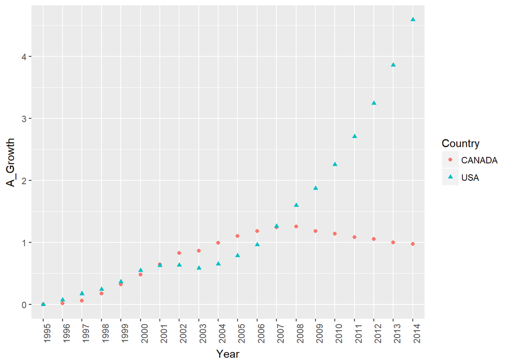

```r
ggplot(
  bind_rows(
     mutate(dfCanada, A_Growth = cumsum(Arrivals /  summarise(dfCanada, first(Arrivals))[,1] - 1)),
     mutate(dfUSA, A_Growth = cumsum(Arrivals /  summarise(dfUSA, first(Arrivals))[,1] - 1))
  ),
  mapping = aes(x = Year, y = A_Growth, color = Country, shape = Country)
) +
  geom_point() +
  theme(axis.text.x = element_text(angle = 90))
```

```r
#geom_smooth()
#geom_bar()
```

Comparing Growth of Departures over the years between USA and Canada

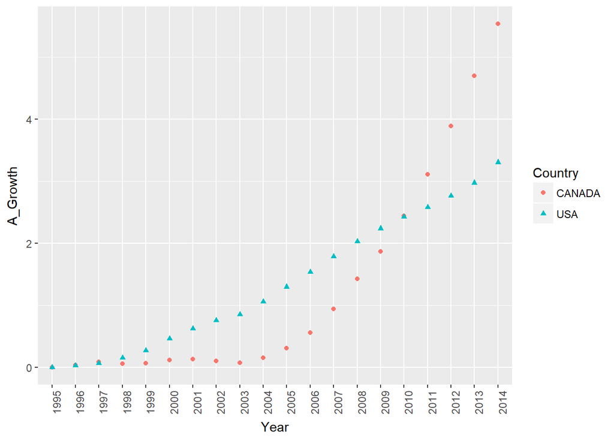

```r
ggplot(
  bind_rows(
     mutate(dfCanada, A_Growth = cumsum(Departures /  summarise(dfCanada, first(Departures))[,1] - 1)),
     mutate(dfUSA, A_Growth = cumsum(Departures /  summarise(dfUSA, first(Departures))[,1] - 1))
  ),
  mapping = aes(x = Year, y = A_Growth, color = Country, shape = Country)
) +
  geom_point() +
  theme(axis.text.x = element_text(angle = 90))
```

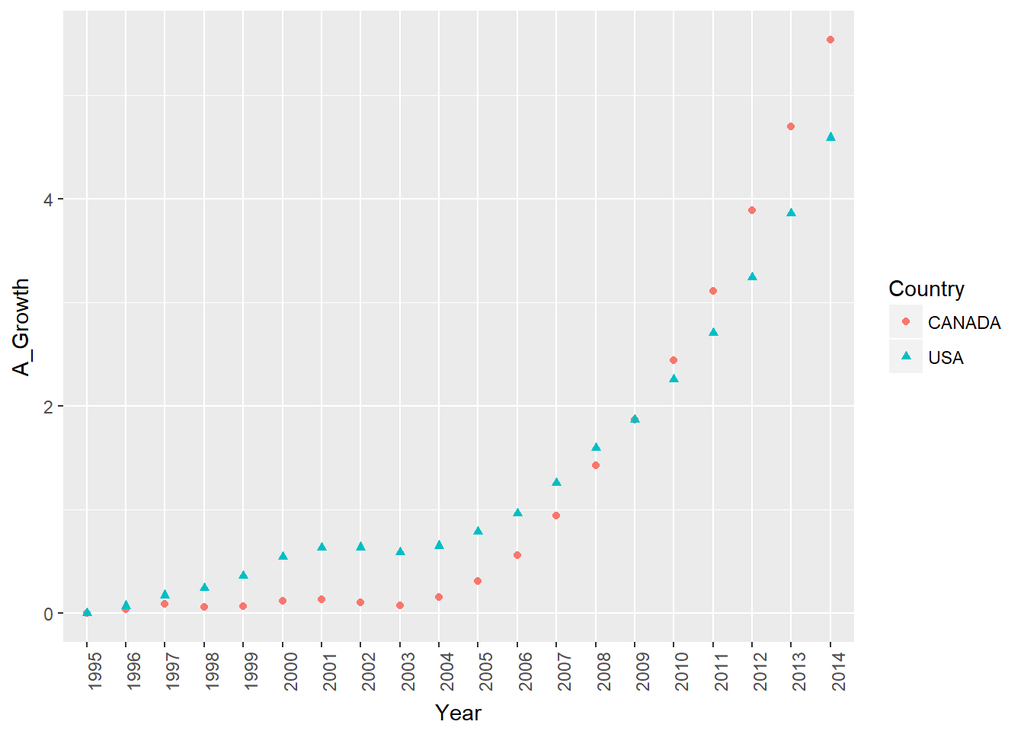

```r
ggplot(
  bind_rows(
     mutate(dfCanada, A_Growth = cumsum(Departures /  summarise(dfCanada, first(Departures))[,1] - 1)),
     mutate(dfUSA, A_Growth = cumsum(Arrivals /  summarise(dfUSA, first(Arrivals))[,1] - 1))
  ),
  mapping = aes(x = Year, y = A_Growth, color = Country, shape = Country)
) +
  geom_point() +
  theme(axis.text.x = element_text(angle = 90))
```